# Stats 141SL Final Project

Hayley Todd

```r
setwd("/Users/Hayley/Downloads/Stats Class Material")
finalproj <- read.csv("Statistics Data  - Page 3.csv", na.strings = c("", "NA"))
#View(finalproj)
```

49 people responded to question 2

```r
textmine <- finalproj[c(1,3)]
textmine
```

| ID | top_words |
| --- | --- |
| SEAN1 | insightful enjoyable interesting detailed beautiful |
| SEAN2 | NA |
| SEAN3 | awareness groupwork positive disjointed applicable |
| SEAN4 | easy simple positive fun relevant applicable crossdisciplinary grouporiented |
| SEAN5 | motivational interesting analytical informative helpful |
| SEAN6 | mindopening meaningful unique informative fun |
| SEAN7 | stats R group openinternet openbook |
| HENNA1 | resourceful good meaningful helpful easy |
| HENNA2 | special wide interesting practical open |
| HENNA3 | review complex groupwork homework reactionpaper |

[output cut: 54 more lines]

```r
library(dplyr)
textmine <- textmine %>% na.omit()
textmine$top_words <- as.character(textmine$top_words)

text_df <- tibble(line = 1:length(textmine$top_words), text = textmine$top_words)

library(tidytext)

text_df <- text_df %>% unnest_tokens(word, text)
#words <- as.data.frame(text_df[,2])
#sort(unique(words[,1]))
```

```r
q2words <- text_df %>% count(word, sort = T)
q2words
```

| word | n |
| --- | --- |
| interesting | 19 |
| diversity | 13 |
| diverse | 10 |
| fun | 10 |
| meaningful | 7 |
| helpful | 6 |
| groupwork | 4 |
| statistics | 4 |
| stats | 4 |
| applicable | 3 |

[output cut: 129 more lines]

Plot of raw words (typos fixed and multiple words combined):

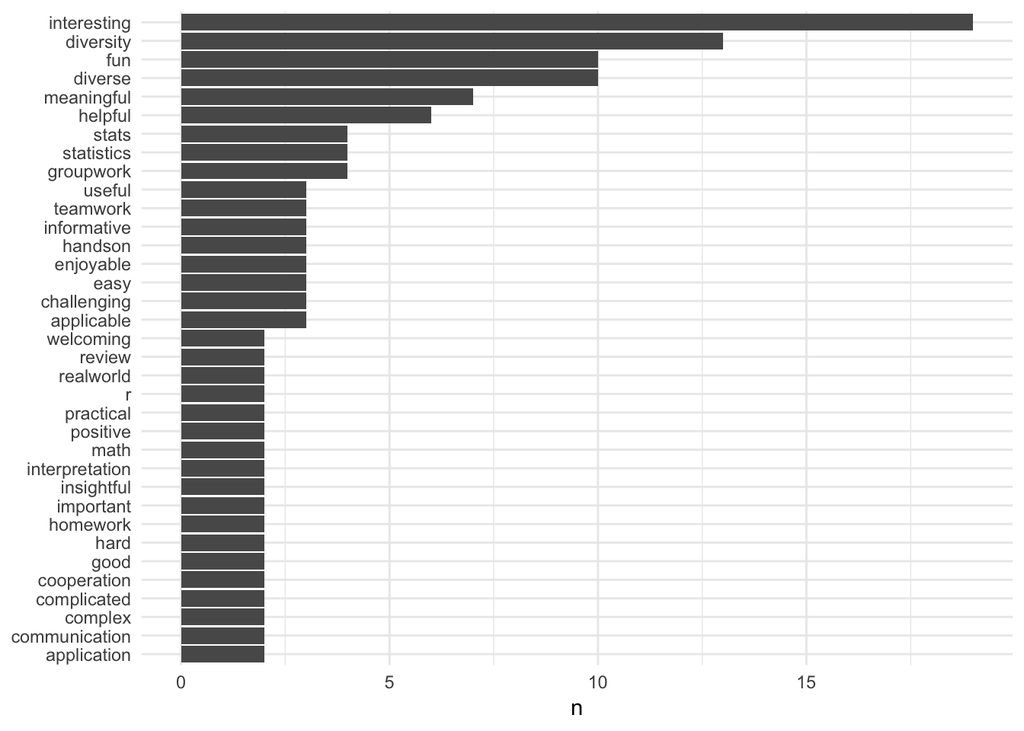

```r
library(ggplot2)
library(dplyr)
library(tidyr)

#texttrial <- text_df %>%
#  count(word, sort = TRUE)

q2words %>% dplyr::filter(n > 1) %>%
  mutate(word = reorder(word, n)) %>%
  ggplot(aes(word, n)) +
  geom_col() +
  xlab(NULL) +
  theme_minimal() +
  coord_flip()
```

```r
#text_df <- texttrial
```

Raw words word cloud:

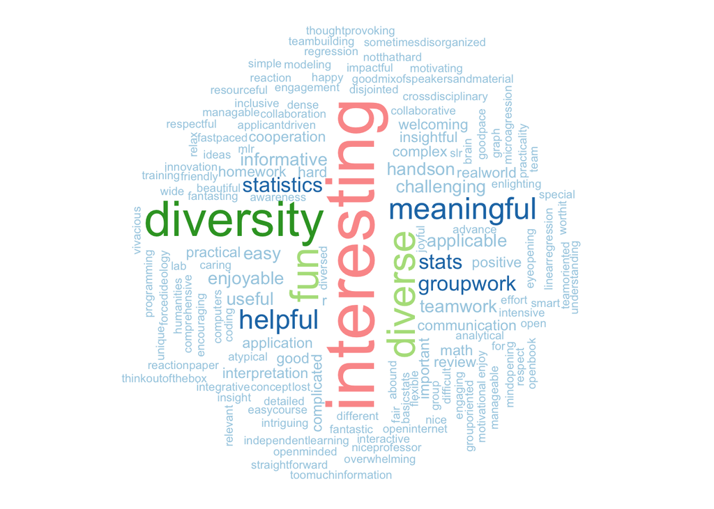

```r
library("wordcloud")
set.seed(135719)
wordcloud(words = q2words$word, freq=q2words$n, min.freq = 1, max.words = 150, random.order = FALSE, rot.per = 0.35, colors = brewer.pal(5, "Paired"))
```

Many words had synonyms or similar themes (such as “diversity” and “diverse”), so we decided to combine those to figure out the major word themes.

Cleaning and combining synonyms/similar themes:

```r
cleantext <- text_df

applicable <- c(which(cleantext[,2] == "application"), which(cleantext[,2] == "applicantdriven"), which(cleantext[,2] == "realworld"), which(cleantext[,2] == "useful"))
cleantext[applicable, 2] <- "applicable"

##########

difficult <- c(which(cleantext[,2] == "challenging"), which(cleantext[,2] == "hard"), which(cleantext[,2] == "intensive"), which(cleantext[,2] == "advance"), which(cleantext[,2] == "complicated"), which(cleantext[,2] == "overwhelming"), which(cleantext[,2] == "toomuchinformation"), which(cleantext[,2] == "dense"))
cleantext[difficult, 2] <- "difficult"

############

complex <- c(which(cleantext[,2] == "comprehensive"), which(cleantext[,2] == "crossdisciplinary"))
cleantext[complex, 2] <- "complex"

###########

collaborative <- c(which(cleantext[,2] == "collaboration"), which(cleantext[,2] == "cooperation"))
cleantext[collaborative, 2] <- "collaborative"

###########

team <- c(which(cleantext[,2] == "group"), which(cleantext[,2] == "groupwork"), which(cleantext[,2] == "teamwork"), which(cleantext[,2] == "teamworking"), which(cleantext[,2] == "teamoriented"))
cleantext[team, 2] <- "team"

###########

diversity <- c(which(cleantext[,2] == "diverse"))
cleantext[diversity, 2] <- "diversity"

###########

easy <- c(which(cleantext[,2] == "notthathard"), which(cleantext[,2] == "easycourse"), which(cleantext[,2] == "simple"))
cleantext[easy, 2] <- "easy"

############

engaging <- c(which(cleantext[,2] == "engagement"))
cleantext[engaging, 2] <- "engaging"

###########

enjoyable <- c(which(cleantext[,2] == "enjoy"), which(cleantext[,2] == "fun"), which(cleantext[,2] == "joyful"), which(cleantext[,2] == "happy"))
cleantext[enjoyable, 2] <- "enjoyable"

############

positive <- c(which(cleantext[,2] == "good"))
cleantext[positive, 2] <- "positive"

############

interactive <- c(which(cleantext[,2] == "handson"))
cleantext[interactive, 2] <- "interactive"

############

insightful <- c(which(cleantext[,2] == "insight"))
cleantext[insightful, 2] <- "insightful"

############

interesting <- c(which(cleantext[,2] == "intriguing"))
cleantext[interesting, 2] <- "interesting"

###########

manageable <- c(which(cleantext[,2] == "managable"))
cleantext[manageable, 2] <- "manageable"

###########

enlightening <- c(which(cleantext[,2] == "mindopening"), which(cleantext[,2] == "thoughtprovoking"), which(cleantext[,2] == "thinkoutofthebox"), which(cleantext[,2] == "enlighting"), which(cleantext[,2] == "eyeopening"))
cleantext[enlightening, 2] <- "enlightening"

###########

motivational <- c(which(cleantext[,2] == "motivating"))
cleantext[motivational, 2] <- "motivational"

###########

practical <- c(which(cleantext[,2] == "practicality"))
cleantext[practical, 2] <- "practical"

###########

coding <- c(which(cleantext[,2] == "r"), which(cleantext[,2] == "programming"), which(cleantext[,2] == "computers"))
cleantext[coding, 2] <- "coding"

###########

reaction <- c(which(cleantext[,2] == "reactionpaper"))
cleantext[reaction, 2] <- "reaction"

###########

respectful <- c(which(cleantext[,2] == "respect"))
cleantext[respectful, 2] <- "respectful"

###########

special <- c(which(cleantext[,2] == "unique"))
cleantext[special, 2] <- "special"

###########

statistics <- c(which(cleantext[,2] == "stats"), which(cleantext[,2] == "basicstats"), which(cleantext[,2] == "analytical"))
cleantext[statistics, 2] <- "statistics"

###########

concepts <- c(which(cleantext[,2] == "linearregression"), which(cleantext[,2] == "mlr"), which(cleantext[,2] == "slr"), which(cleantext[,2] == "regression"), which(cleantext[,2] == "math"), which(cleantext[,2] == "modeling"))
cleantext[concepts, 2] <- "concepts"

###########
head(cleantext)
```

| line | word |
| --- | --- |
| 1 | insightful |
| 1 | enjoyable |
| 1 | interesting |
| 1 | detailed |
| 1 | beautiful |
| 2 | awareness |

```r
q2themewords <- cleantext %>% count(word, sort = TRUE)
q2themewords
```

| word | n |
| --- | --- |
| diversity | 23 |
| interesting | 20 |
| enjoyable | 16 |
| difficult | 13 |
| applicable | 11 |
| statistics | 10 |
| team | 10 |
| concepts | 7 |
| meaningful | 7 |
| easy | 6 |

[output cut: 75 more lines]

Plot of cleaned words:

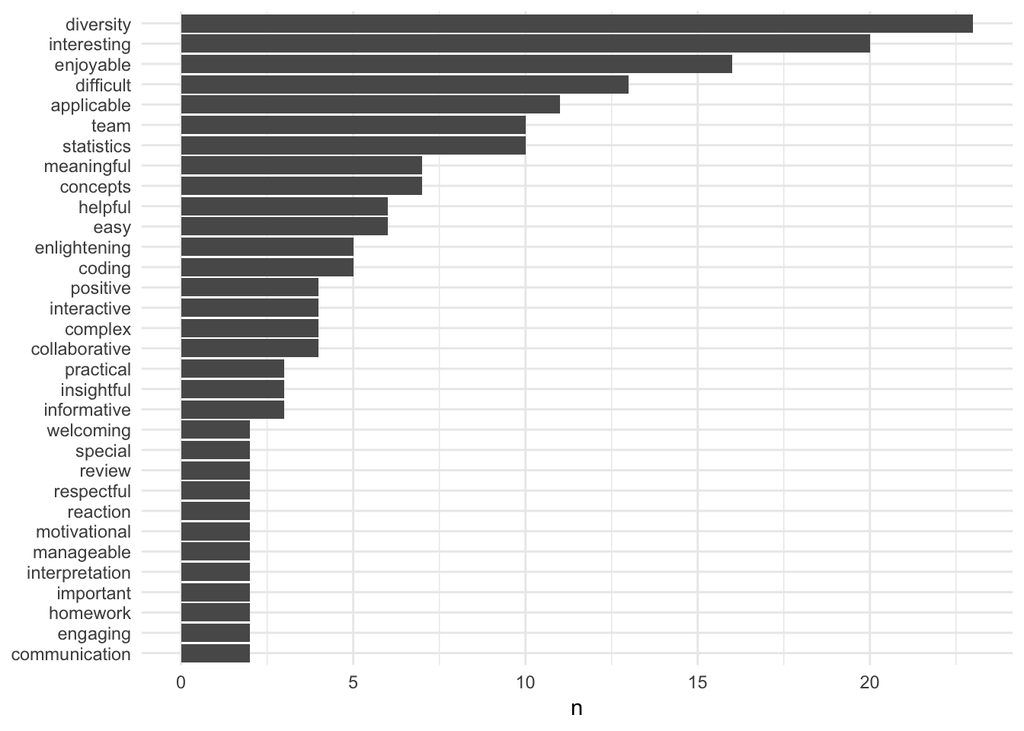

```r
library(ggplot2)
library(dplyr)
library(tidyr)
#cleantext
#cleantext <- cleantext %>%
#  arrange(desc(n))

q2themewords %>% dplyr::filter(n > 1) %>%
  mutate(word = reorder(word, n)) %>%
  ggplot(aes(word, n)) +
  geom_col() +
  xlab(NULL) +
  theme_minimal() +
  coord_flip()
```

```r
#cleantext %>%
#  count(word, sort = TRUE) %>%
#  filter(n > 1) %>%
#  mutate(word = reorder(word, n)) %>%
#  ggplot(aes(word, n)) +
#  geom_col() +
#  xlab(NULL) +
#  theme_minimal() +
#  coord_flip()
```

Word Cloud of Cleaned Words:

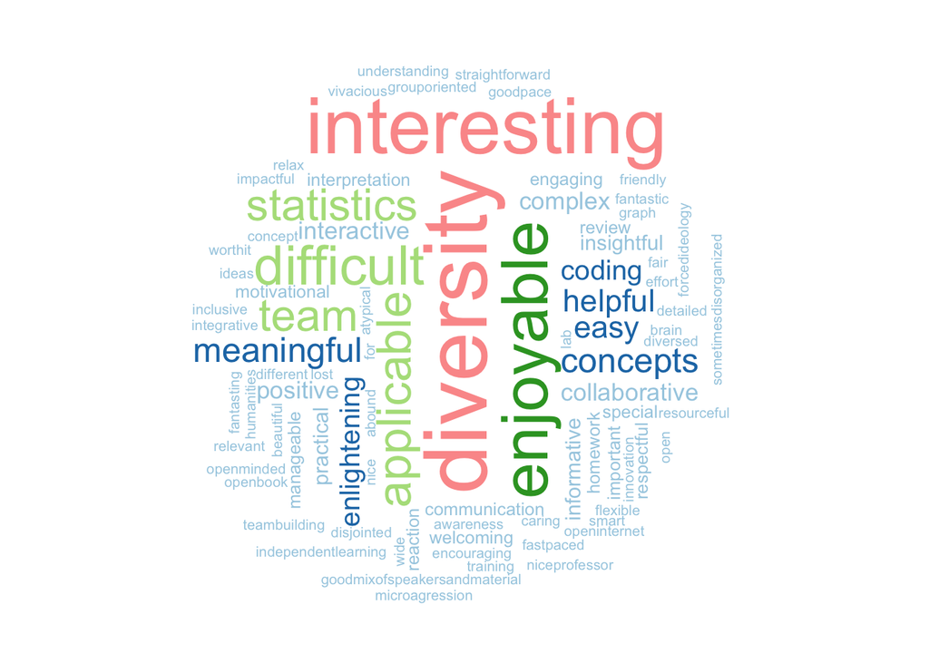

```r
library("wordcloud")
set.seed(2019)
wordcloud(words = q2themewords$word, freq=q2themewords$n, min.freq = 1, max.words = 150, random.order = FALSE, rot.per = 0.35, colors = brewer.pal(5, "Paired"))
```

Some exploratory analysis:

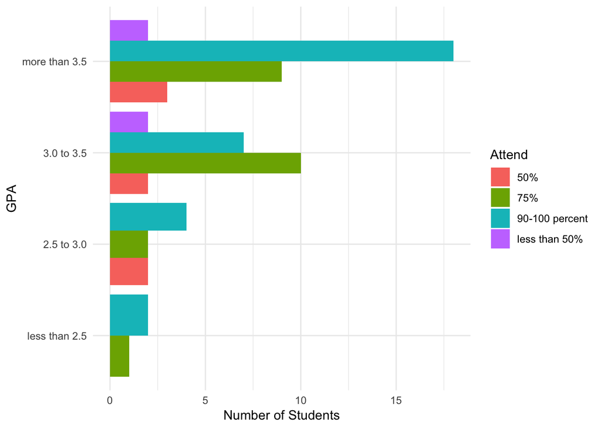

```r
page1 <- read.csv("Statistics Data  - Page 1.csv", na.strings = c("", "NA"))
#library(plyr)
#View(page1)

page1$GPA <- ordered(page1$GPA, levels = c("less than 2.5", "2.5 to 3.0", "3.0 to 3.5", "more than 3.5"))

ggplot(page1, aes(x = GPA,fill = Attend)) + geom_bar(position = position_dodge()) + theme_minimal() + coord_flip() + labs(y = "Number of Students")
```

Large amount of students had a GPA of 3.5 or higher. Those who had 3.5 or higher mostly attended 90-100% of classes. People with 3.0-3.5 mostly attended 75% of class.

```r
combo <- cbind(page1, finalproj[,3])
#View(combo)
```

```r
cleantext <- cleantext %>% group_by(line) %>% summarise(words = paste(word, collapse=" "))
cleantext$ID <- textmine$ID
cleantext <- cleantext[,-1]
FINALDF <- full_join(combo, cleantext, by = "ID")
FINALDF <- FINALDF[,-21]
FINALDF
```

| ID | Major | INT | Minor | Trans | Gender | GPA | Attend | English | Recommend | microagg | understanding | guest_speakers | reaction_papers | stats_lec | stats_hw | diverse_campus1 | diverse_world1 | diverse_campus2 | diverse_world2 | words |
| --- | --- | --- | --- | --- | --- | --- | --- | --- | --- | --- | --- | --- | --- | --- | --- | --- | --- | --- | --- | --- |
| SEAN1 | Math | No | NA | Yes | Male | 3.0 to 3.5 | 75% | No | Yes | 5 | 4 | 5 | 4 | 5 | 5 | 5 | 5 | 5 | 5 | insightful enjoyable interesting detailed beautiful |
| SEAN2 | FAM | Yes | NA | Yes | Female | 3.0 to 3.5 | 90-100 percent | No | Yes | 4 | 4 | 4 | 4 | 5 | 5 | 5 | 5 | 5 | 5 | NA |
| SEAN3 | Statistics | No | NA | Yes | Male | 2.5 to 3.0 | 90-100 percent | Yes | Yes | 4 | 3 | 5 | 5 | 2 | 2 | 4 | 4 | 3 | 4 | awareness team positive disjointed applicable |
| SEAN4 | Statistics | No | NA | Yes | Female | 3.0 to 3.5 | less than 50% | Yes | Yes | 5 | 5 | 5 | 5 | 5 | 5 | 5 | 5 | 2 | 2 | easy easy positive enjoyable relevant applicable complex grouporiented |
| SEAN5 | Statistics | Yes | NA | Yes | Female | more than 3.5 | 75% | No | Yes | 4 | 4 | 4 | 4 | 4 | 4 | 4 | 4 | 4 | 4 | motivational interesting statistics informative helpful |
| SEAN6 | Business Economics | No | Accounting | No | Female | more than 3.5 | 90-100 percent | No | Yes | 5 | 5 | 5 | 5 | 5 | 5 | 5 | 5 | 5 | 5 | enlightening meaningful special informative enjoyable |
| SEAN7 | Statistics | Yes | NA | Yes | Male | 3.0 to 3.5 | 75% | No | Yes | 4 | 4 | 5 | 3 | 4 | 3 | 4 | 4 | 3 | 3 | statistics coding team openinternet openbook |
| HENNA1 | Statistics, FAM | No | NA | Yes | Male | more than 3.5 | 90-100 percent | No | Yes | 4 | 4 | 4 | 4 | 4 | 4 | 4 | 3 | 4 | 4 | resourceful positive meaningful helpful easy |
| HENNA2 | Statistics | Yes | NA | Yes | Female | more than 3.5 | 90-100 percent | No | Yes | 4 | 5 | 4 | 3 | 4 | 5 | 5 | 5 | 4 | 4 | special wide interesting practical open |
| HENNA3 | Statistics | Yes | NA | Yes | Male | more than 3.5 | 75% | No | Yes | 4 | 5 | 3 | 2 | 3 | 3 | 4 | 5 | 3 | 3 | review complex team homework reaction |

[output cut: 54 more lines]

```r
summary(FINALDF)
```

```
##         ID              Major     INT                Minor    Trans
##  BREANNA1: 1   Statistics  :27   No :31   Statistics    : 7   No :26
##  BREANNA2: 1   Sociology   : 6   Yes:33   Music Industry: 2   Yes:38
##  BREANNA3: 1   Math        : 5                          : 1
##  BREANNA4: 1   Applied Math: 4            Accounting    : 1
##  BREANNA5: 1   FAM         : 3            Accounting    : 1
##  BREANNA6: 1   IDS         : 3            (Other)       :11
##  (Other) :58   (Other)     :16            NA's          :41
##     Gender              GPA                Attend   English   Recommend
##  Female:35   less than 2.5: 3   50%           : 7   No  :43   No : 5
##  Male  :29   2.5 to 3.0   : 8   75%           :22   No  : 4   Yes:59
##              3.0 to 3.5   :21   90-100 percent:31   Yes :16
##              more than 3.5:32   less than 50% : 4   Yes : 1
##
##
##
##     microagg     understanding   guest_speakers  reaction_papers
##  Min.   :1.000   Min.   :2.000   Min.   :2.000   Min.   :2.000
##  1st Qu.:4.000   1st Qu.:3.000   1st Qu.:4.000   1st Qu.:3.000
##  Median :4.000   Median :4.000   Median :4.000   Median :4.000
##  Mean   :4.047   Mean   :3.891   Mean   :4.078   Mean   :3.547
##  3rd Qu.:5.000   3rd Qu.:4.000   3rd Qu.:5.000   3rd Qu.:4.000
##  Max.   :5.000   Max.   :5.000   Max.   :5.000   Max.   :5.000
##
##    stats_lec        stats_hw     diverse_campus1 diverse_world1
##  Min.   :2.000   Min.   :2.000   Min.   :2.000   Min.   :2.000
##  1st Qu.:4.000   1st Qu.:3.000   1st Qu.:3.750   1st Qu.:3.250
##  Median :4.000   Median :4.000   Median :4.000   Median :4.000
##  Mean   :4.016   Mean   :3.969   Mean   :3.953   Mean   :3.871
##  3rd Qu.:4.250   3rd Qu.:5.000   3rd Qu.:4.250   3rd Qu.:4.000
##  Max.   :5.000   Max.   :5.000   Max.   :5.000   Max.   :5.000
##                                                  NA's   :2
##  diverse_campus2 diverse_world2     words
##  Min.   :1.0     Min.   :2.000   Length:64
##  1st Qu.:3.0     1st Qu.:3.000   Class :character
##  Median :4.0     Median :4.000   Mode  :character
##  Mean   :3.5     Mean   :3.594
##  3rd Qu.:4.0     3rd Qu.:4.000
##  Max.   :5.0     Max.   :5.000
##
```

We wanted to look into the various characteristics and see if different groups expressed different opinions or concerns about the class:

** INTERNATIONAL/NON INTERNATIONAL STUDENTS: **

International Student Responses (raw):

```r
comboint <- combo[which(combo$INT == "Yes"),]
intwords <- comboint[,21]

combonotint <- combo[which(combo$INT == "No"),]
notintwords <- combonotint[,21]

sum(is.na(comboint[,21]) == F)
```

```
## [1] 22
```

```r
sum(is.na(combonotint[,21]) == F)
```

```
## [1] 27
```

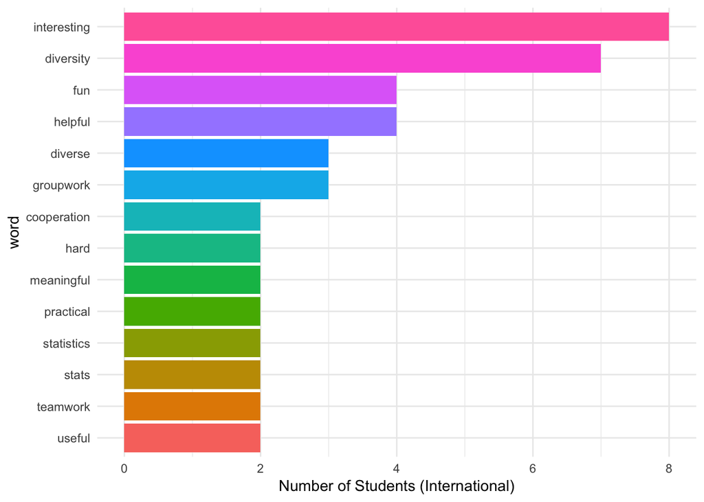

```r
library(dplyr)

intwords <- intwords %>% na.omit()
intwords <- as.character(intwords)

intwords <- tibble(line = 1:length(intwords), text = intwords)

library(tidytext)

intwords <- intwords %>% unnest_tokens(word, text)
intwordsdf <- as.data.frame(intwords[,2])
#intwordsdf
library(ggplot2)


q2intwords <- intwordsdf %>%
  count(word, sort = TRUE) %>%
  dplyr::filter(n > 1)

#q2intwords

q2intwords$word <- factor(q2intwords$word, levels = rev(factor(q2intwords$word)))

ggplot(q2intwords, aes(x = word, y = n, fill = word)) + geom_bar(stat = "identity") + coord_flip() + theme_minimal() + theme(legend.position = "none") + labs(y ="Number of Students (International)")
```

International Student Responses (clean):

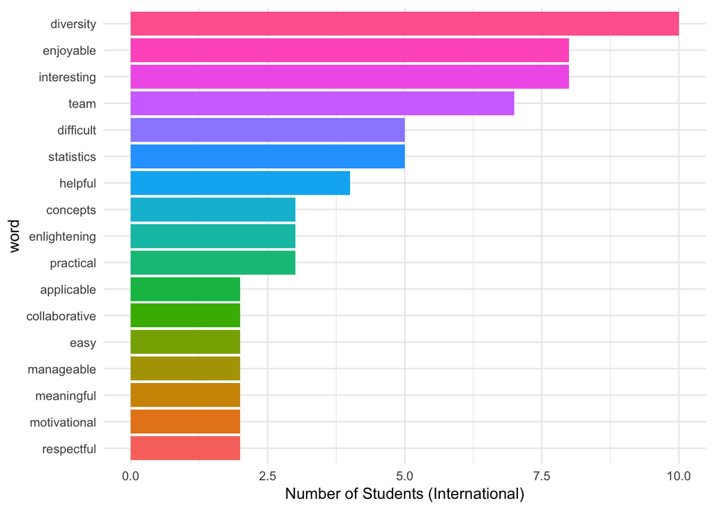

```r
cleanint <- FINALDF[which(FINALDF$INT == "Yes"),]
cleanintwords <- cleanint[,21]

cleannotint <- FINALDF[which(FINALDF$INT == "No"),]
cleannotintwords <- cleannotint[,21]

library(dplyr)

cleanintwords <- cleanintwords %>% na.omit()
cleanintwords <- as.character(cleanintwords)

cleanintwords <- tibble(line = 1:length(cleanintwords), text = cleanintwords)

library(tidytext)

cleanintwords <- cleanintwords %>% unnest_tokens(word, text)
cleanintwordsdf <- as.data.frame(cleanintwords[,2])
#cleanintwordsdf
library(ggplot2)

q2cleanintwords <- cleanintwordsdf %>%
  count(word, sort = TRUE) %>%
  dplyr::filter(n > 1)
#q2cleanintwords

q2cleanintwords$word <- factor(q2cleanintwords$word, levels = rev(factor(q2cleanintwords$word)))

ggplot(q2cleanintwords, aes(x = word, y = n, fill = word)) + geom_bar(stat = "identity") + coord_flip() + theme_minimal() + theme(legend.position = "none") + labs(y ="Number of Students (International)")
```

Non-International Student Responses (clean):

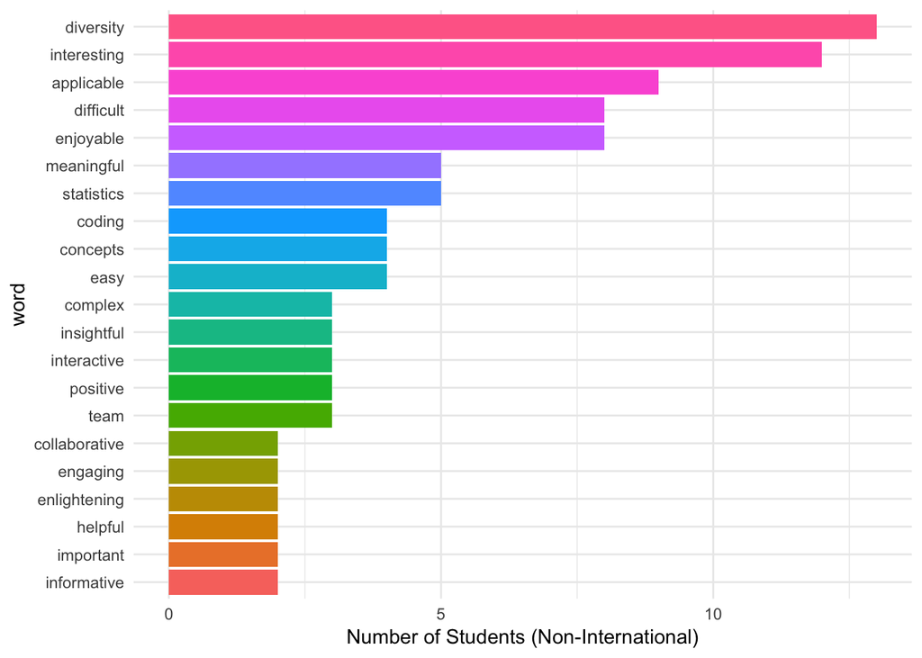

```r
library(dplyr)

cleannotintwords <- cleannotintwords %>% na.omit()
cleannotintwords <- as.character(cleannotintwords)

cleannotintwords <- tibble(line = 1:length(cleannotintwords), text = cleannotintwords)

library(tidytext)

cleannotintwords <- cleannotintwords %>% unnest_tokens(word, text)
cleannotintwordsdf <- as.data.frame(cleannotintwords[,2])

library(ggplot2)

q2cleannotintwords <- cleannotintwordsdf %>%
  count(word, sort = TRUE) %>%
  dplyr::filter(n > 1)
#q2cleanintwords

q2cleannotintwords$word <- factor(q2cleannotintwords$word, levels = rev(factor(q2cleannotintwords$word)))

ggplot(q2cleannotintwords, aes(x = word, y = n, fill = word)) + geom_bar(stat = "identity") + coord_flip() + theme_minimal() + theme(legend.position = "none") + labs(y ="Number of Students (Non-International)")
```

Top 5 themes for international students: diversity, interesting, enjoyable, team, difficult.

Top 5 themes for non international students: diversity, interesting, applicable, enjoyable, difficult.

Not very different. ___________________________________________________________________________________________

**Separating by GPA:**

```r
gpa1 <- FINALDF[which(FINALDF$GPA == "less than 2.5"),]
gpa1words <- gpa1[,21]

gpa2 <- FINALDF[which(FINALDF$GPA == "2.5 to 3.0"),]
gpa2words <- gpa2[,21]

gpa3 <- FINALDF[which(FINALDF$GPA == "3.0 to 3.5"),]
gpa3words <- gpa3[,21]

gpa4 <- FINALDF[which(FINALDF$GPA == "more than 3.5"),]
gpa4words <- gpa4[,21]
```

GPA below 2.5:

```r
library(dplyr)

gpa1words <- gpa1words %>% na.omit()
gpa1words <- as.character(gpa1words)

gpa1words <- tibble(line = 1:length(gpa1words), text = gpa1words)

library(tidytext)

gpa1words <- gpa1words %>% unnest_tokens(word, text)
gpa1words
```

| line | word |
| --- | --- |
| 1 | applicable |
| 1 | applicable |
| 1 | interactive |
| 1 | training |
| 1 | forcedideology |
| 2 | diversity |
| 2 | enjoyable |
| 2 | interesting |
| 2 | helpful |
| 2 | collaborative |

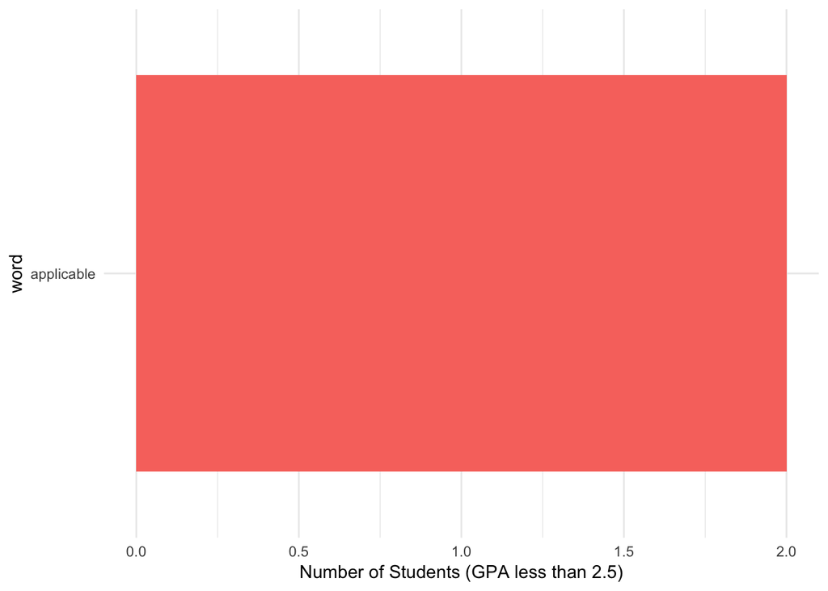

```r
gpa1wordsdf <- as.data.frame(gpa1words[,2])
library(ggplot2)

q2gpa1words <- gpa1wordsdf %>%
  count(word, sort = TRUE) %>%
  dplyr::filter(n > 1)

q2gpa1words$word <- factor(q2gpa1words$word, levels = rev(factor(q2gpa1words$word)))

ggplot(q2gpa1words, aes(x = word, y = n, fill = word)) + geom_bar(stat = "identity") + coord_flip() + theme_minimal() + theme(legend.position = "none") + labs(y ="Number of Students (GPA less than 2.5)")
```

Not many people have GPA below 2.5.

GPA between 2.5 and 3.0:

```r
library(dplyr)

gpa2words <- gpa2words %>% na.omit()
gpa2words <- as.character(gpa2words)

gpa2words <- tibble(line = 1:length(gpa2words), text = gpa2words)

library(tidytext)

gpa2words <- gpa2words %>% unnest_tokens(word, text)
gpa2words
```

| line | word |
| --- | --- |
| 1 | awareness |
| 1 | team |
| 1 | positive |
| 1 | disjointed |
| 1 | applicable |
| 2 | enjoyable |
| 2 | brain |
| 2 | concepts |
| 2 | difficult |
| 2 | positive |

[output cut: 20 more lines]

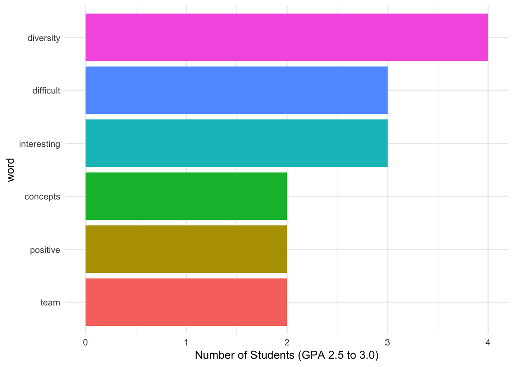

```r
gpa2wordsdf <- as.data.frame(gpa2words[,2])
library(ggplot2)

q2gpa2words <- gpa2wordsdf %>%
  count(word, sort = TRUE) %>%
  dplyr::filter(n > 1)

q2gpa2words$word <- factor(q2gpa2words$word, levels = rev(factor(q2gpa2words$word)))

ggplot(q2gpa2words, aes(x = word, y = n, fill = word)) + geom_bar(stat = "identity") + coord_flip() + theme_minimal() + theme(legend.position = "none") + labs(y ="Number of Students (GPA 2.5 to 3.0)")
```

Also not many people have GPA between 2.5 to 3.0. However, out of those people, most people said “diversity”, “difficult”, and “interesting”.

GPA between 3.0 and 3.5:

```r
library(dplyr)

gpa3words <- gpa3words %>% na.omit()
gpa3words <- as.character(gpa3words)

gpa3words <- tibble(line = 1:length(gpa3words), text = gpa3words)

library(tidytext)

gpa3words <- gpa3words %>% unnest_tokens(word, text)
gpa3words
```

| line | word |
| --- | --- |
| 1 | insightful |
| 1 | enjoyable |
| 1 | interesting |
| 1 | detailed |
| 1 | beautiful |
| 2 | easy |
| 2 | easy |
| 2 | positive |
| 2 | enjoyable |
| 2 | relevant |

[output cut: 71 more lines]

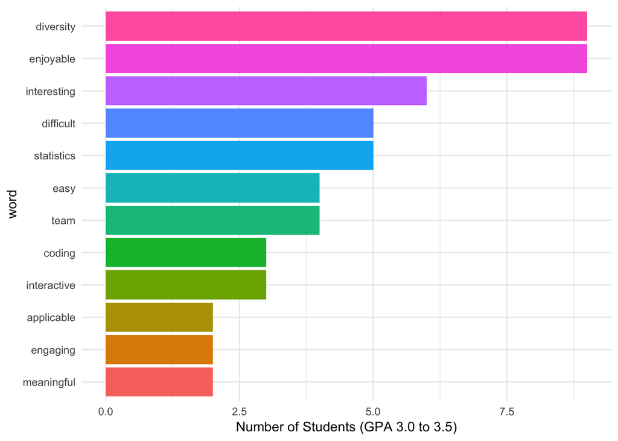

```r
gpa3wordsdf <- as.data.frame(gpa3words[,2])
library(ggplot2)

q2gpa3words <- gpa3wordsdf %>%
  count(word, sort = TRUE) %>%
  dplyr::filter(n > 1)

q2gpa3words$word <- factor(q2gpa3words$word, levels = rev(factor(q2gpa3words$word)))

ggplot(q2gpa3words, aes(x = word, y = n, fill = word)) + geom_bar(stat = "identity") + coord_flip() + theme_minimal() + theme(legend.position = "none") + labs(y ="Number of Students (GPA 3.0 to 3.5)")
```

Most use “diversity”, “enjoyable”, and “interesting”.

GPA about 3.5:

```r
library(dplyr)

gpa4words <- gpa4words %>% na.omit()
gpa4words <- as.character(gpa4words)

gpa4words <- tibble(line = 1:length(gpa4words), text = gpa4words)

library(tidytext)

gpa4words <- gpa4words %>% unnest_tokens(word, text)
gpa4words
```

| line | word |
| --- | --- |
| 1 | motivational |
| 1 | interesting |
| 1 | statistics |
| 1 | informative |
| 1 | helpful |
| 2 | enlightening |
| 2 | meaningful |
| 2 | special |
| 2 | informative |
| 2 | enjoyable |

[output cut: 110 more lines]

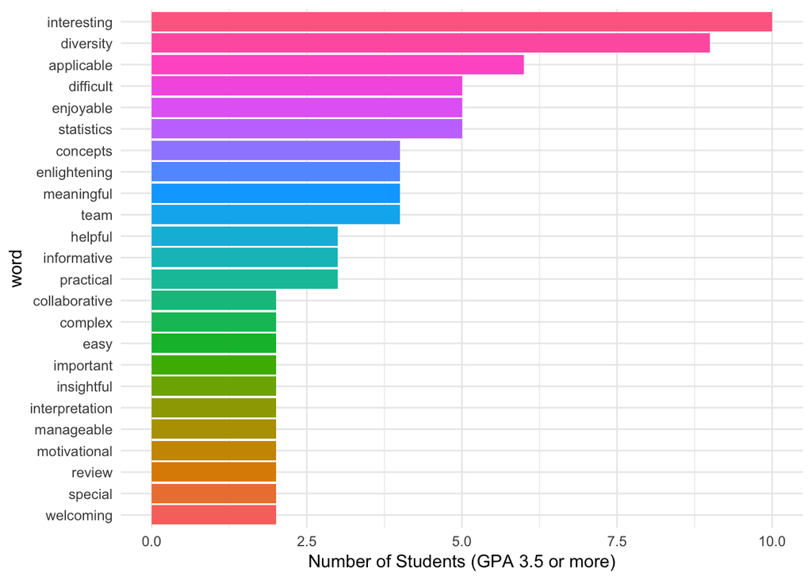

```r
gpa4wordsdf <- as.data.frame(gpa4words[,2])
library(ggplot2)

q2gpa4words <- gpa4wordsdf %>%
  count(word, sort = TRUE) %>%
  dplyr::filter(n > 1)

q2gpa4words$word <- factor(q2gpa4words$word, levels = rev(factor(q2gpa4words$word)))

ggplot(q2gpa4words, aes(x = word, y = n, fill = word)) + geom_bar(stat = "identity") + coord_flip() + theme_minimal() + theme(legend.position = "none") + labs(y ="Number of Students (GPA 3.5 or more)")
```

Most used “interesting”, “diversity”, and “applicable”.

Putting all plots together:

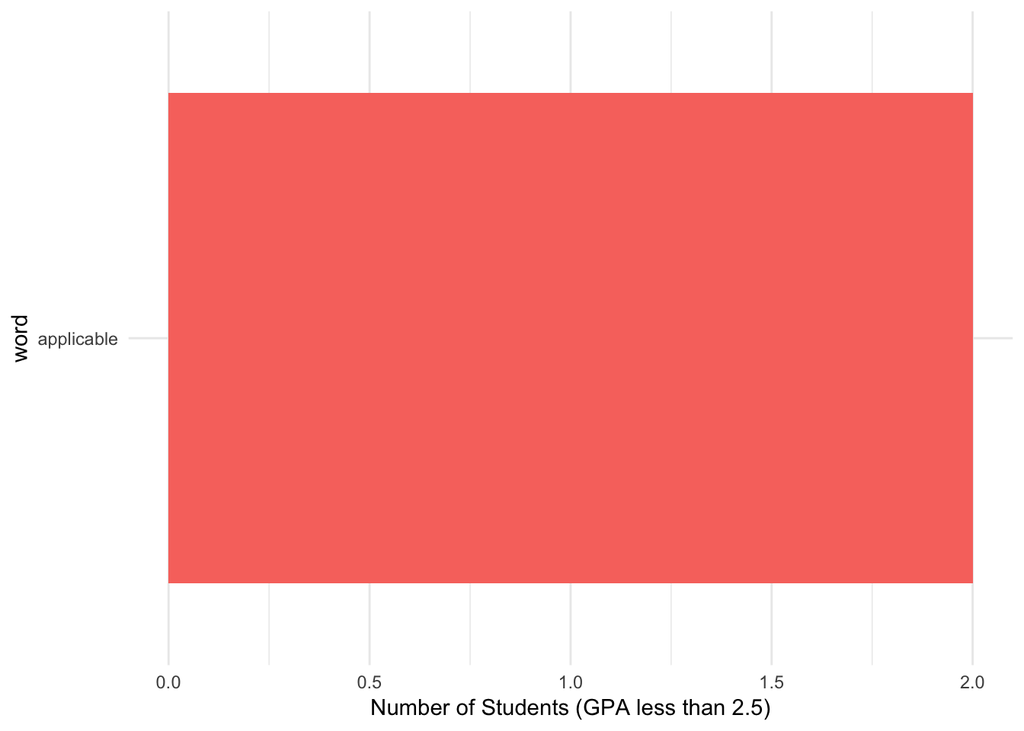

```r
#summary(FINALDF)
par(mfrow = c(2,2))
ggplot(q2gpa1words, aes(x = word, y = n, fill = word)) + geom_bar(stat = "identity") + coord_flip() + theme_minimal() + theme(legend.position = "none") + labs(y ="Number of Students (GPA less than 2.5)")
```

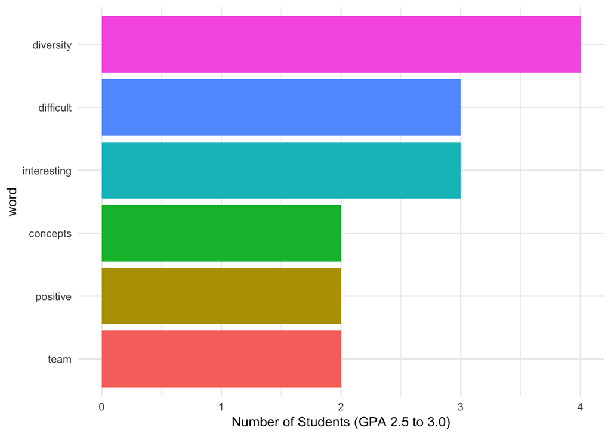

```r
ggplot(q2gpa2words, aes(x = word, y = n, fill = word)) + geom_bar(stat = "identity") + coord_flip() + theme_minimal() + theme(legend.position = "none") + labs(y ="Number of Students (GPA 2.5 to 3.0)")
```

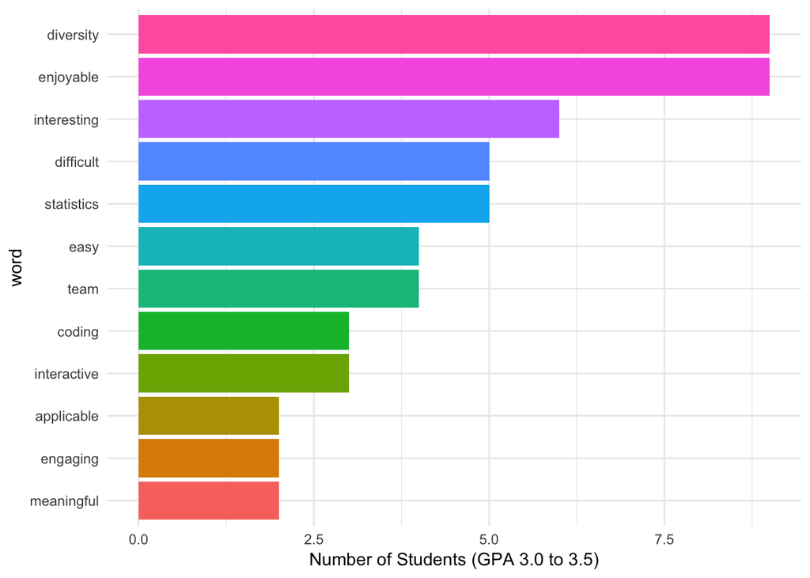

```r
ggplot(q2gpa3words, aes(x = word, y = n, fill = word)) + geom_bar(stat = "identity") + coord_flip() + theme_minimal() + theme(legend.position = "none") + labs(y ="Number of Students (GPA 3.0 to 3.5)")
```

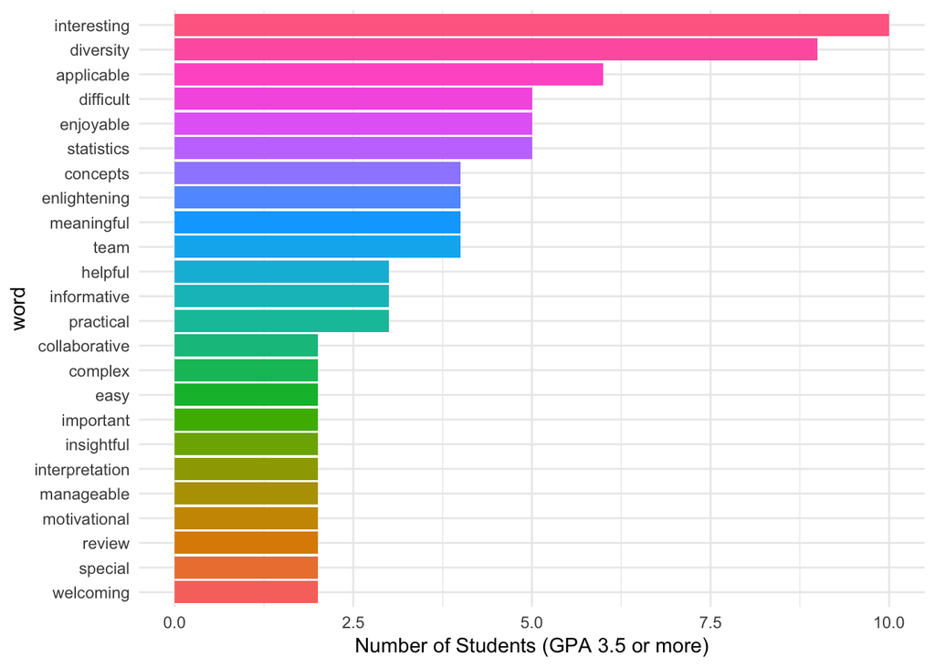

```r
ggplot(q2gpa4words, aes(x = word, y = n, fill = word)) + geom_bar(stat = "identity") + coord_flip() + theme_minimal() + theme(legend.position = "none") + labs(y ="Number of Students (GPA 3.5 or more)")
```

Recommend:

3/5 did not respond to Page 3 - Question 2.

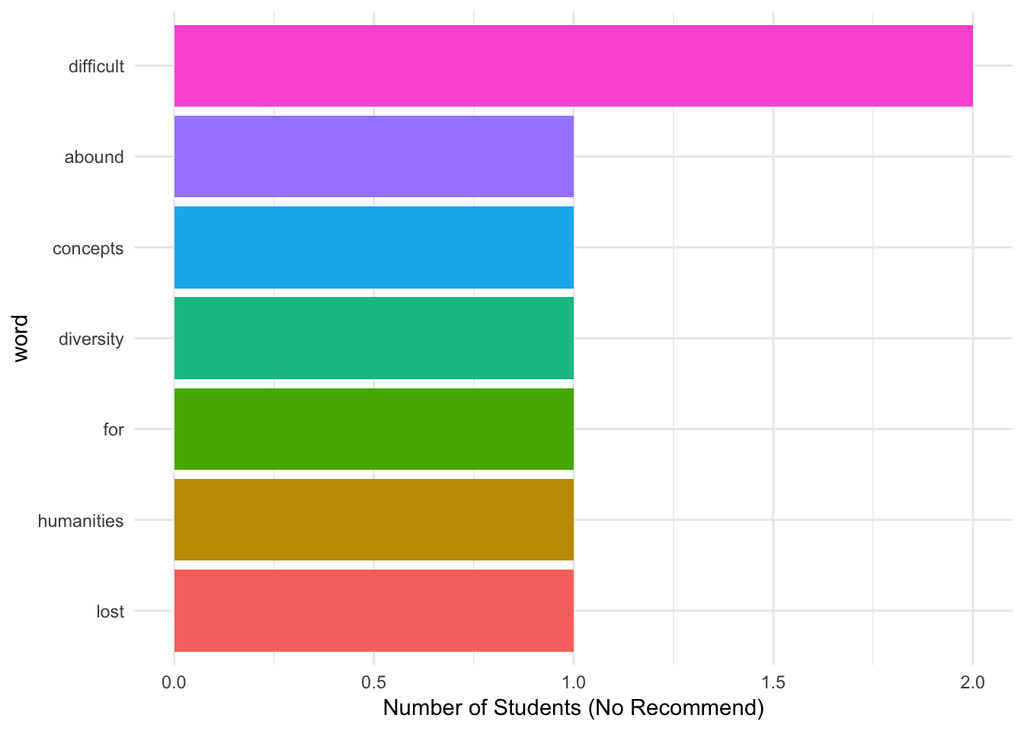

```r
cleannotrec <- FINALDF[which(FINALDF$Recommend == "No"),]
cleannotrecwords <- cleannotrec[,21]

library(dplyr)

cleannotrecwords <- cleannotrecwords %>% na.omit()
cleannotrecwords <- as.character(cleannotrecwords)

cleannotrecwords <- tibble(line = 1:length(cleannotrecwords), text = cleannotrecwords)

library(tidytext)

cleannotrecwords <- cleannotrecwords %>% unnest_tokens(word, text)
cleannotrecwordsdf <- as.data.frame(cleannotrecwords[,2])
#cleanintwordsdf
library(ggplot2)

q2cleannotrecwords <- cleannotrecwordsdf %>%
  count(word, sort = TRUE) #%>%
#  filter(n > 1)

q2cleannotrecwords$word <- factor(q2cleannotrecwords$word, levels = rev(factor(q2cleannotrecwords$word)))

ggplot(q2cleannotrecwords, aes(x = word, y = n, fill = word)) + geom_bar(stat = "identity") + coord_flip() + theme_minimal() + theme(legend.position = "none") + labs(y ="Number of Students (No Recommend)")
```

Not many people did not recommend the class.

**Statistics Majors vs Non-Statistics Majors:**

```r
finalpage1 <- read.csv("Copy of Statistics Data  - Page 1.csv", na.strings = c("", "NA"))
finalpage3 <- read.csv("Copy of Statistics Data  - Page 3.csv", na.strings = c("", "NA"))
finalpage1$words <- finalpage3[,3]

library(dplyr)
#textmine <- textmine %>% na.omit()

finalpage1$words <- as.character(finalpage1$words)

majortext_df <- tibble(line = 1:length(finalpage1$words), text = finalpage1$words)

library(tidytext)

majortext_df <- majortext_df %>% unnest_tokens(word, text) %>% na.omit()
majortext_df
```

| line | word |
| --- | --- |
| 1 | insightful |
| 1 | enjoyable |
| 1 | interesting |
| 1 | detailed |
| 1 | beautiful |
| 3 | awareness |
| 3 | groupwork |
| 3 | positive |
| 3 | disjointed |
| 3 | applicable |

[output cut: 261 more lines]

```r
cleanmajortext <- majortext_df

applicable <- c(which(cleanmajortext[,2] == "application"), which(cleanmajortext[,2] == "applicantdriven"), which(cleanmajortext[,2] == "realworld"), which(cleanmajortext[,2] == "useful"))
cleanmajortext[applicable, 2] <- "applicable"

##########

difficult <- c(which(cleanmajortext[,2] == "challenging"), which(cleanmajortext[,2] == "hard"), which(cleanmajortext[,2] == "intensive"), which(cleanmajortext[,2] == "advance"), which(cleanmajortext[,2] == "complicated"), which(cleanmajortext[,2] == "overwhelming"), which(cleanmajortext[,2] == "toomuchinformation"), which(cleanmajortext[,2] == "dense"))
cleanmajortext[difficult, 2] <- "difficult"

############

complex <- c(which(cleanmajortext[,2] == "comprehensive"), which(cleanmajortext[,2] == "crossdisciplinary"))
cleanmajortext[complex, 2] <- "complex"

###########

collaborative <- c(which(cleanmajortext[,2] == "collaboration"), which(cleanmajortext[,2] == "cooperation"))
cleanmajortext[collaborative, 2] <- "collaborative"

###########

team <- c(which(cleanmajortext[,2] == "group"), which(cleanmajortext[,2] == "groupwork"), which(cleanmajortext[,2] == "teamwork"), which(cleanmajortext[,2] == "teamworking"), which(cleanmajortext[,2] == "teamoriented"))
cleanmajortext[team, 2] <- "team"

###########

diversity <- c(which(cleanmajortext[,2] == "diverse"))
cleanmajortext[diversity, 2] <- "diversity"

###########

easy <- c(which(cleanmajortext[,2] == "notthathard"), which(cleanmajortext[,2] == "easycourse"), which(cleanmajortext[,2] == "simple"))
cleanmajortext[easy, 2] <- "easy"

############

engaging <- c(which(cleanmajortext[,2] == "engagement"))
cleanmajortext[engaging, 2] <- "engaging"

###########

enjoyable <- c(which(cleanmajortext[,2] == "enjoy"), which(cleanmajortext[,2] == "fun"), which(cleanmajortext[,2] == "joyful"), which(cleanmajortext[,2] == "happy"))
cleanmajortext[enjoyable, 2] <- "enjoyable"

############

positive <- c(which(cleanmajortext[,2] == "good"))
cleanmajortext[positive, 2] <- "positive"

############

interactive <- c(which(cleantext[,2] == "handson"))
cleantext[interactive, 2] <- "interactive"
############

insightful <- c(which(cleanmajortext[,2] == "insight"))
cleanmajortext[insightful, 2] <- "insightful"

############

interesting <- c(which(cleanmajortext[,2] == "intriguing"))
cleanmajortext[interesting, 2] <- "interesting"

###########

manageable <- c(which(cleanmajortext[,2] == "managable"))
cleanmajortext[manageable, 2] <- "manageable"

###########

enlightening <- c(which(cleanmajortext[,2] == "mindopening"), which(cleanmajortext[,2] == "thoughtprovoking"), which(cleanmajortext[,2] == "thinkoutofthebox"), which(cleanmajortext[,2] == "enlighting"), which(cleanmajortext[,2] == "eyeopening"))
cleanmajortext[enlightening, 2] <- "enlightening"

###########

motivational <- c(which(cleanmajortext[,2] == "motivating"))
cleanmajortext[motivational, 2] <- "motivational"

###########

practical <- c(which(cleanmajortext[,2] == "practicality"))
cleanmajortext[practical, 2] <- "practical"

###########

coding <- c(which(cleanmajortext[,2] == "r"), which(cleanmajortext[,2] == "programming"), which(cleanmajortext[,2] == "computers"))
cleanmajortext[coding, 2] <- "coding"

###########

reaction <- c(which(cleanmajortext[,2] == "reactionpaper"))
cleanmajortext[reaction, 2] <- "reaction"

###########

respectful <- c(which(cleanmajortext[,2] == "respect"))
cleanmajortext[respectful, 2] <- "respectful"

###########

special <- c(which(cleanmajortext[,2] == "unique"))
cleanmajortext[special, 2] <- "special"

###########

statistics <- c(which(cleanmajortext[,2] == "stats"), which(cleanmajortext[,2] == "basicstats"), which(cleanmajortext[,2] == "analytical"))
cleanmajortext[statistics, 2] <- "statistics"

###########

concepts <- c(which(cleanmajortext[,2] == "linearregression"), which(cleanmajortext[,2] == "mlr"), which(cleanmajortext[,2] == "slr"), which(cleanmajortext[,2] == "regression"), which(cleanmajortext[,2] == "math"), which(cleanmajortext[,2] == "modeling"))
cleanmajortext[concepts, 2] <- "concepts"

###########

cleanmajortext <- cleanmajortext %>% group_by(line) %>% summarise(words = paste(word, collapse=" "))
finalpage1$line <- c(1:70)
cleanmajortext <- dplyr::full_join(finalpage1, cleanmajortext, by = "line")
cleanmajortext <- cleanmajortext[,-c(21:22)]
```

```r
statsmajor <- cleanmajortext[which(cleanmajortext$Major == "Statistics"),]
statsmajorwords <- statsmajor[,21]

nonstatsmajor <- cleanmajortext[which(cleanmajortext$Major != "Statistics"),]
nonstatsmajorwords <- nonstatsmajor[,21]
```

Words Used by Statistics Majors (clean):

```r
library(dplyr)

statsmajorwords <- statsmajorwords %>% na.omit()
statsmajorwords <- as.character(statsmajorwords)

statsmajorwords <- tibble(line = 1:length(statsmajorwords), text = statsmajorwords)

library(tidytext)

statsmajorwords <- statsmajorwords %>% unnest_tokens(word, text)
statsmajorwords
```

| line | word |
| --- | --- |
| 1 | awareness |
| 1 | team |
| 1 | positive |
| 1 | disjointed |
| 1 | applicable |
| 2 | easy |
| 2 | easy |
| 2 | positive |
| 2 | enjoyable |
| 2 | relevant |

[output cut: 119 more lines]

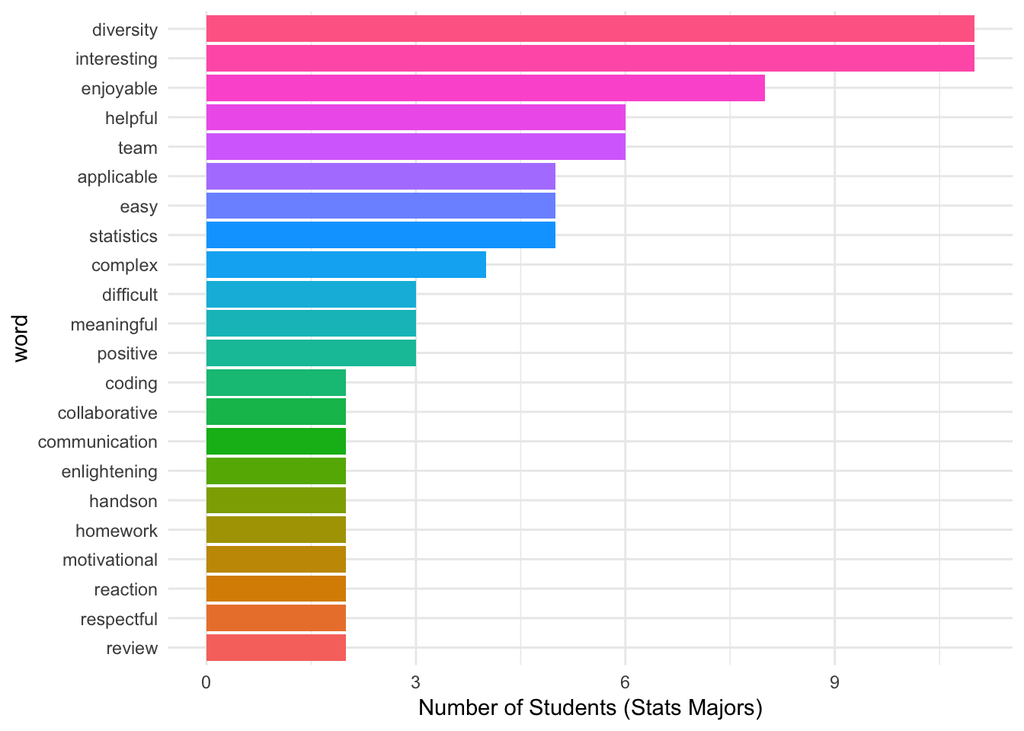

```r
statswordsdf <- as.data.frame(statsmajorwords[,2])
library(ggplot2)

q2statswords <- statswordsdf %>%
  count(word, sort = TRUE) %>%
  dplyr::filter(n > 1)

q2statswords$word <- factor(q2statswords$word, levels = rev(factor(q2statswords$word)))

ggplot(q2statswords, aes(x = word, y = n, fill = word)) + geom_bar(stat = "identity") + coord_flip() + theme_minimal() + theme(legend.position = "none") + labs(y ="Number of Students (Stats Majors)")
```

Words Used by Non-Statistics Majors:

```r
library(dplyr)

nonstatsmajorwords <- nonstatsmajorwords %>% na.omit()
nonstatsmajorwords <- as.character(nonstatsmajorwords)

nonstatsmajorwords <- tibble(line = 1:length(nonstatsmajorwords), text = nonstatsmajorwords)

library(tidytext)

nonstatsmajorwords <- nonstatsmajorwords %>% unnest_tokens(word, text)
nonstatsmajorwords
```

| line | word |
| --- | --- |
| 1 | insightful |
| 1 | enjoyable |
| 1 | interesting |
| 1 | detailed |
| 1 | beautiful |
| 2 | enlightening |
| 2 | meaningful |
| 2 | special |
| 2 | informative |
| 2 | enjoyable |

[output cut: 132 more lines]

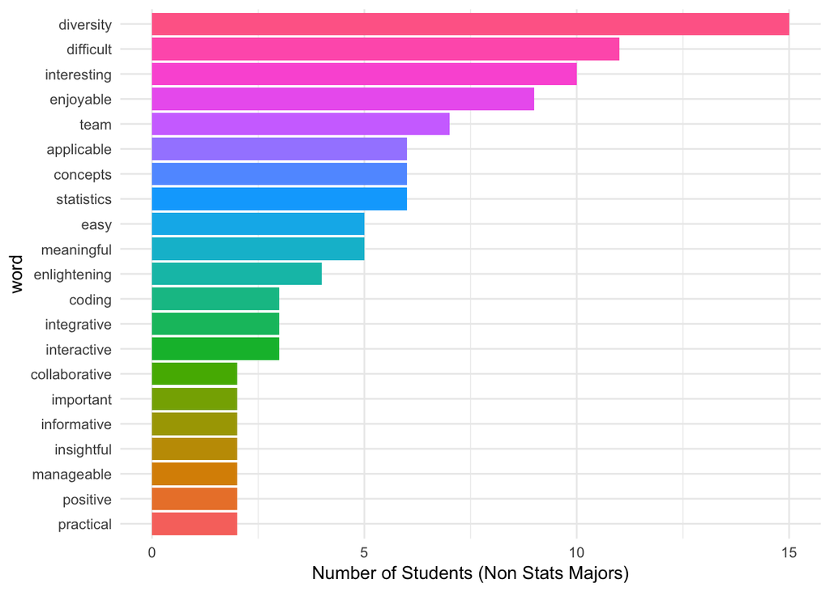

```r
nonstatswordsdf <- as.data.frame(nonstatsmajorwords[,2])
library(ggplot2)

q2nonstatswords <- nonstatswordsdf %>%
  count(word, sort = TRUE) %>%
  dplyr::filter(n > 1)

q2nonstatswords$word <- factor(q2nonstatswords$word, levels = rev(factor(q2nonstatswords$word)))

ggplot(q2nonstatswords, aes(x = word, y = n, fill = word)) + geom_bar(stat = "identity") + coord_flip() + theme_minimal() + theme(legend.position = "none") + labs(y ="Number of Students (Non Stats Majors)")
```

Graphically Depicting Words Used by Statistics Majors vs Non-Statistics Majors:

- 50/50 split between Statistics and Non-Statistics Majors (including double majors).

```r
majorcombo <- dplyr::full_join(q2nonstatswords, q2statswords, by = "word")
```

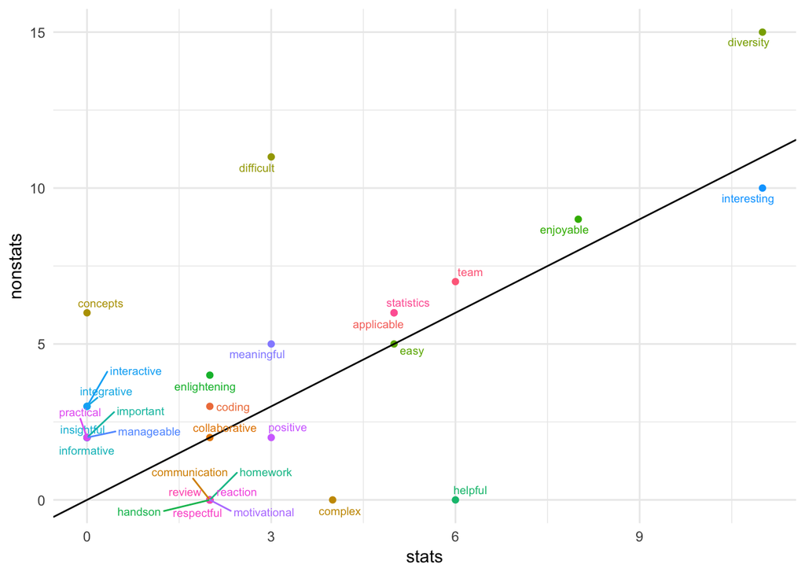

```r
colnames(majorcombo)[c(2,3)] <- c("nonstats","stats")
majorcombo <- majorcombo %>% replace_na(list(nonstats = 0, stats = 0))


library(ggrepel)
ggplot(majorcombo, aes(x = stats, y = nonstats, col = word, label = word)) + geom_point() + theme_minimal() + theme(legend.position = "none") + geom_abline(intercept = 0, slope = 1) + geom_text_repel(aes(label = word), size = 2.5)
```